# STIC data processing and report

Christopher Wheeler

4/6/2022

## STIC Processing Workflow

```r
library(tidyverse)
library(cowplot)
library(dygraphs)
library(patchwork)
library(sf)
```

I have developed some generalized functions for tidying and preliminary processing of STIC data that I intend to make into a package. Code for the functions is below:

The first function loads raw HOBO STIC files and cleans up columns and headers to produce a tidy data frame and/or CSV output.

infile = filename (including path if needed) for the raw HOBO data on your computer.

outfile = filename (including path if needed) to save the tidied. Defaults to FALSE, in which case tidied data will not be saved.

```r
source("tidy_hobo_data.R")
```

This next function (get_calibration.R) is a function to fit standard and measured calibration data to model a object (lm and exponential to start)

inputs: data frame with columns “standard” and “conductivity_uncal” and method = “linear” or “exponential”

output: fitted model object

input needs to be data frame. column names: conductivity_uncal, standard

```r
source("get_calibration.R")
```

The next function is called apply_calibration.R

inputs: calibration (a model object) and a data frame with columns labeled “datetime”, “temperature” “conductivity_uncal”

output: same data frame as input, except with a new column called “spc”

```r
source("apply_calibration.R")
```

Last function is classify_wetdry.R

inputs: data frame with columns “datetime”, “temperature”, “conductivity”, and “specific_conductivity”

output: same data frame as input, but with a new column called wetdry

```r
source("classify_wetdry.R")
```

## Examples of the use of STICr functions

Here is how they work:

```r
stic_data <- tidy_hobo_data("C:/Users/cwhee/Desktop/R_Directory/AIMS_hydro_qaqc/youngmeyer_stics_round_1/21038945_ENM312.csv")

head(stic_data)
```

```
##              datetime conductivity_uncal temperature
## 1 2021-07-16 17:00:00              139.9      35.435
## 2 2021-07-16 17:15:00               86.1      36.837
## 3 2021-07-16 17:30:00               96.9      34.374
## 4 2021-07-16 17:45:00              139.9      33.639
## 5 2021-07-16 18:00:00              118.4      33.953
## 6 2021-07-16 18:15:00              150.7      32.497
```

Next we are bringing in a set of calibration points and creating a fitted model object. In this case, the model type we chose is linear

```r
cal_points <- read_csv("cal_points.csv")
cal_points <- cal_points %>%
  rename(standard = std_val) %>%
  rename(conductivity_uncal = measured_val)

calibration_data <- cal_points

calibration <- get_calibration(calibration_data, method = "linear")

summary(calibration)
```

```
##
## Call:
## lm(formula = standard ~ conductivity_uncal, data = calibration_data)
##
## Residuals:
##       1       2       3       4
##   73.77  -50.25 -146.38  122.87
##
## Coefficients:
##                      Estimate Std. Error t value Pr(>|t|)
## (Intercept)        -2.766e+02  1.853e+02  -1.493   0.2740
## conductivity_uncal  1.047e-02  2.402e-03   4.357   0.0488 *
## ---
## Signif. codes:  0 '***' 0.001 '**' 0.01 '*' 0.05 '.' 0.1 ' ' 1
##
## Residual standard error: 149.1 on 2 degrees of freedom
## Multiple R-squared:  0.9047, Adjusted R-squared:  0.8571
## F-statistic: 18.99 on 1 and 2 DF,  p-value: 0.04884
```

Now Step 3: Apply calibration. The function take the current data frame and model object, then adds a new “real” spc column to data frame

```r
stic_data_with_spc <- apply_calibration(stic_data, calibration)

head(stic_data_with_spc)
```

```
##              datetime conductivity_uncal temperature       spc
## 1 2021-07-16 17:00:00              139.9      35.435 -275.1632
## 2 2021-07-16 17:15:00               86.1      36.837 -275.7264
## 3 2021-07-16 17:30:00               96.9      34.374 -275.6133
## 4 2021-07-16 17:45:00              139.9      33.639 -275.1632
## 5 2021-07-16 18:00:00              118.4      33.953 -275.3883
## 6 2021-07-16 18:15:00              150.7      32.497 -275.0502
```

Final step: using the classify_wetdry function to create another column with the binary, classified data. Default threshold is 1000 for conductivity_uncal

```r
classified <- classify_wetdry(stic_data_with_spc,classify_var = "spc", threshold = 50)

head(classified)
```

```
##              datetime conductivity_uncal temperature       spc wetdry
## 1 2021-07-16 17:00:00              139.9      35.435 -275.1632    dry
## 2 2021-07-16 17:15:00               86.1      36.837 -275.7264    dry
## 3 2021-07-16 17:30:00               96.9      34.374 -275.6133    dry
## 4 2021-07-16 17:45:00              139.9      33.639 -275.1632    dry
## 5 2021-07-16 18:00:00              118.4      33.953 -275.3883    dry
## 6 2021-07-16 18:15:00              150.7      32.497 -275.0502    dry
```

Last thing: we need to change “negative” calibrated spc values to 0

```r
classified$spc <- ifelse(classified$spc < 0, 0, classified$spc)
```

## What does this data (for one stic) look like

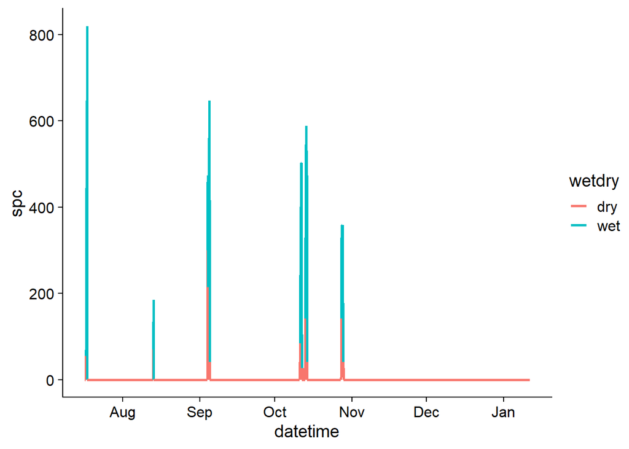

```r
ggplot(classified, aes(x = datetime, y = spc, color = wetdry, group = 1)) +
  geom_path(size = 1) +
  theme_cowplot()
```

Here is a temperature time series

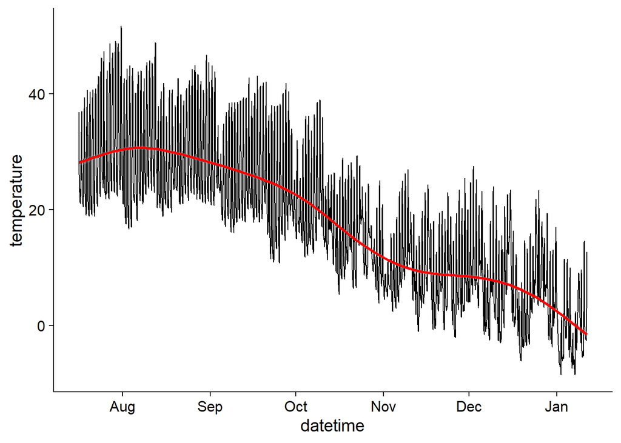

```r
ggplot(classified, aes(x = datetime, y = temperature)) +
  geom_path() +
  geom_smooth(color = "red") +
  theme_cowplot()
```

Here is some code showing how to bring all the STIC locations in and calculate metrics:

```r
library(fs)
library(Rcpp)
library(sp)
library(raster)
library(rgdal)
library(rasterVis)
library(sf)
```

```r
data_dir <- "processed_files_youngmeyer"

fs::dir_ls(data_dir)
```

```
## processed_files_youngmeyer/processed_20821662.csv
## processed_files_youngmeyer/processed_20946456.csv
## processed_files_youngmeyer/processed_20946457.csv
## processed_files_youngmeyer/processed_20946462.csv
## processed_files_youngmeyer/processed_20946471.csv
## processed_files_youngmeyer/processed_20946474.csv
## processed_files_youngmeyer/processed_21035971.csv
## processed_files_youngmeyer/processed_21035972.csv
## processed_files_youngmeyer/processed_21035973.csv
## processed_files_youngmeyer/processed_21035974.csv
## processed_files_youngmeyer/processed_21035975.csv
## processed_files_youngmeyer/processed_21035977.csv
## processed_files_youngmeyer/processed_21038939.csv
## processed_files_youngmeyer/processed_21038941.csv
## processed_files_youngmeyer/processed_21038945.csv
## processed_files_youngmeyer/processed_21038946.csv
## processed_files_youngmeyer/processed_21038947.csv
## processed_files_youngmeyer/processed_21038948.csv
## processed_files_youngmeyer/processed_21038952.csv
```

```r
length(data_dir)
```

```
## [1] 1
```

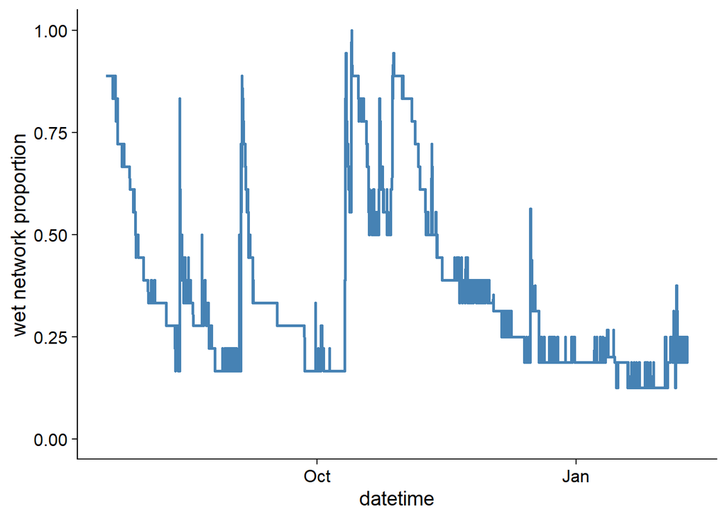

```r
stic_files <- fs::dir_ls(data_dir, regexp = "\\.csv$")

### using the map_dfr function from tidyverse to loop in individual csvs and bind rows
stic_files <- stic_files %>%
  map_dfr(read_csv)

### Creating binary wet/dry column based of relative cond value of 1000
stic_files <- stic_files %>%
  dplyr::mutate(wetdry = if_else(conductivity >= 1000, "wet", "dry" ))

### using lubridate to convert datetime to tidy format
stic_files <- stic_files %>%
  mutate(datetime = lubridate::mdy_hms(datetime))

### Cutting off dates to begin at 07/18/2021
stic_files <- stic_files %>%
  filter(datetime >= "2021-07-18")

### using lubridate to create column with just date rather than datetime
stic_files <- stic_files %>%
  mutate(date = lubridate::date(datetime))

### using lubridate to separate out the individual days
stic_files <- stic_files %>%
  mutate(day = lubridate::yday(date))


### making a new dataframe with date of first drying for all individual logger
drying <- stic_files %>%
  subset(wetdry == "dry") %>%
  group_by(logger) %>%
  summarise(first_dry = min(day))

### Now calculating the percentage of wet STICs at each time step
### Calculate wet network proportion

stic_wet_prop <- stic_files %>%
  group_by(datetime) %>%
  summarise(n_wet = sum(wetdry == "wet"), n_sensors = n() ) %>%
  mutate(percent = n_wet/n_sensors)

ggplot(stic_wet_prop, aes(x = datetime, y = percent)) +
  geom_line(color = "steelblue", size = 1) +
  ylab("wet network proportion") +
  theme_cowplot()
```

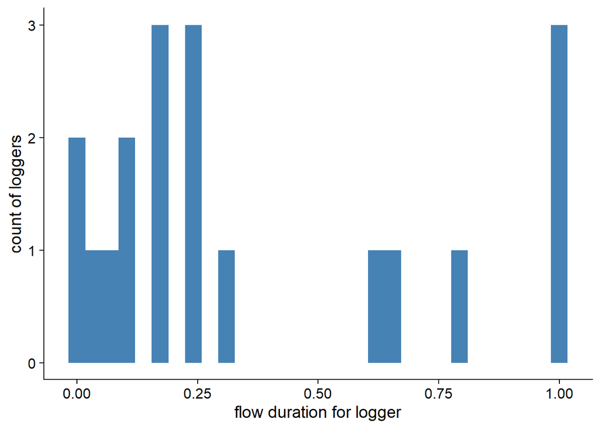

```r
### Calculate flow duration for each sensor
### i,e, percentage of wet observations out of total obs for each logger

stic_duration <- stic_files %>%
  group_by(logger) %>%
  summarise(n_wet = sum(wetdry == "wet", na.rm = TRUE), count = n()) %>%
  mutate(duration = n_wet/count)

ggplot(stic_duration, aes(x = duration)) +
  geom_histogram(fill = "steelblue") +
  theme_cowplot() +
  xlab("flow duration for logger") +
  ylab("count of loggers")
```

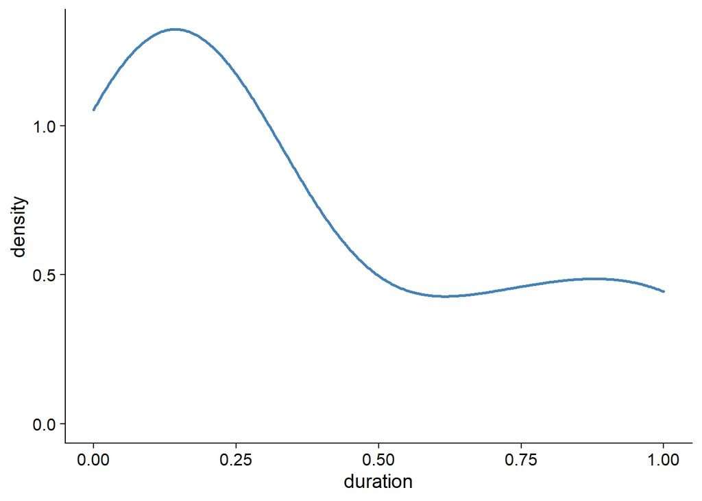

```r
ggplot(stic_duration, aes(x = duration)) +
  geom_density(color = "steelblue", size = 1) +
  theme_cowplot()
```

Now we are pairing with a coordinate data frame to create some maps. First we are just going to map the location of ENM312

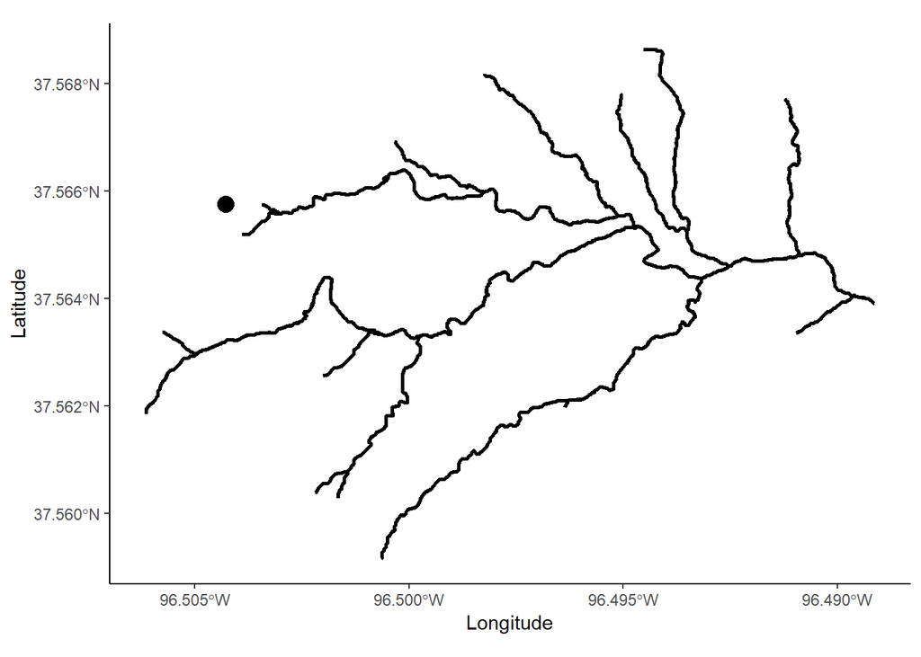

```r
library(tidyverse)
library(tidyr)

youngmeyer_coords <- read_csv("youngmeyer_coords.csv",
                              col_types = cols(logger = col_number()))

stic_duration$logger <- as.numeric(stic_duration$logger)

duration_coords <- left_join(youngmeyer_coords, stic_duration, by = "logger")

### Make Duration Map


youngmeyer_duration_locs <- st_as_sf(duration_coords,
                                     coords = c("Longitude", "Latitude"),
                                     crs = 4326)


youngmeyer_cal <- read_csv("youngmeyer_cal.csv",
                           col_types = cols(logger = col_number()))


young_spc_stic <- left_join(stic_files, youngmeyer_cal, by = "logger")

young_spc_stic <- drop_na(young_spc_stic)

young_spc_stic <- young_spc_stic %>%
  mutate(spc = conductivity/slope)


young_spc_wet_stic <- young_spc_stic %>%
  filter(wetdry == "wet")

# generate average cond value
young_ave_cond <- young_spc_wet_stic %>%
  group_by(logger) %>%
  summarise(average_spc = mean(spc))

# map the mean spc

youngmeyer_coords <- read_csv("youngmeyer_coords.csv",
                              col_types = cols(logger = col_number()))


spc_coords <- left_join(youngmeyer_coords, young_ave_cond, by = "logger")

### Make SPC Map

youngmeyer_spc_locs <- st_as_sf(spc_coords,
                                coords = c("Longitude", "Latitude"),
                                crs = 4326)

# Put in stream network shapefile


youngmeyer_streams <- st_read(
  "youngmeyer_shape/Youngmeyer_StreamNetwork.shp")
# Make single map

enm312_loc <- youngmeyer_duration_locs %>%
  filter(Site == "ENM312")


ggplot() +
  geom_sf(data = youngmeyer_streams, size = 1) +
  geom_sf(data = enm312_loc, size = 4) +
  scale_color_viridis_c() +
  theme_classic() +
  xlab("Longitude") +
  ylab("Latitude")
```

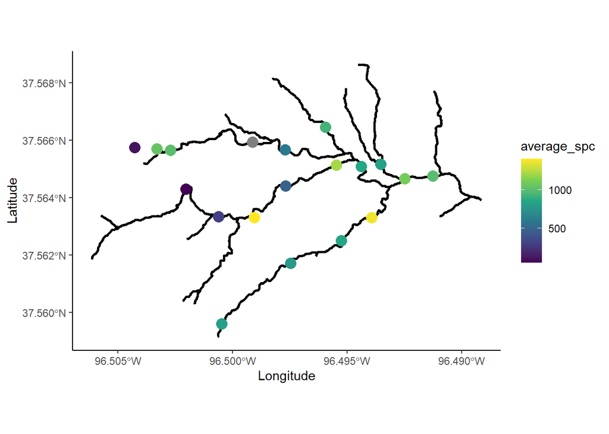

```r
# Make New Maps with Stream Lines

# ave spc
ggplot() +
  geom_sf(data = youngmeyer_streams, size = 1) +
  geom_sf(data = youngmeyer_spc_locs, aes(color = average_spc), size = 4) +
  scale_color_viridis_c() +
  theme_classic() +
  xlab("Longitude") +
  ylab("Latitude")
```

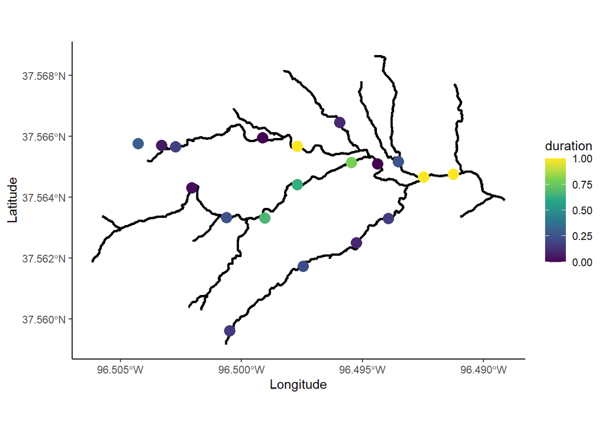

```r
ggplot() +
  geom_sf(data = youngmeyer_streams, size = 1) +
  geom_sf(data = youngmeyer_duration_locs, aes(color = duration), size = 4) +
  scale_color_viridis_c() +
  theme_classic() +
  xlab("Longitude") +
  ylab("Latitude")
```